# res_vpaの読み込み

- **設定ポイント:** vpa関数の引数fc.yearで指定した年数が今後current FのFとして扱われます。

```r
library(frasyr)
library(tidyverse)
data(res_vpa)
res_vpa$Fc.at.age # 将来予測やMSY計算で使うcurrent Fを確認してプロットする
```

```
#>         0         1         2         3
#> 0.4901521 1.1503151 1.3131002 1.3131001
```

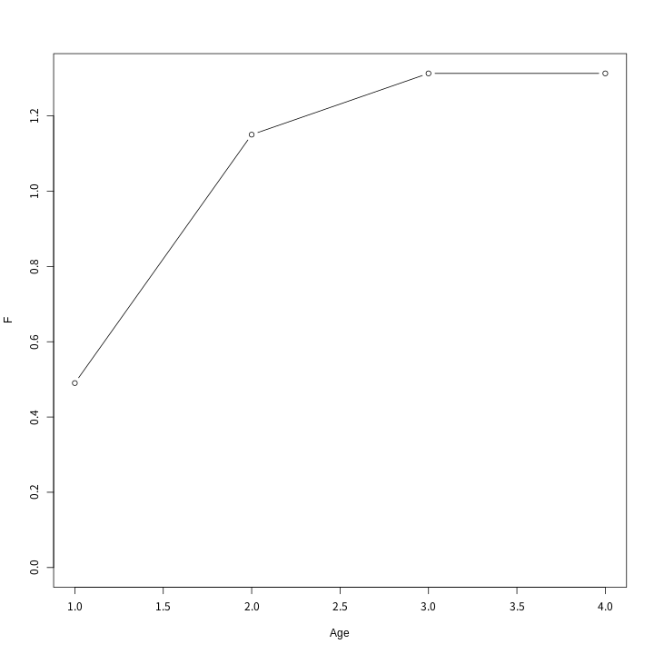

```r
plot(res_vpa$Fc.at.age,type="b",xlab="Age",ylab="F",ylim=c(0,max(res_vpa$Fc.at.age)))
```

```r
# 独自のFc.at.ageを使いたい場合は以下のようにここで指定する
# res_vpa$Fc.at.age[] <- c(1,1,2,2)
```

# 再生産関係の推定

```r
# VPA結果を使って再生産データを作る
SRdata <- get.SRdata(res_vpa, years=1988:2016)
head(SRdata)
```

```
#> $year
#>  [1] 1988 1989 1990 1991 1992 1993 1994 1995 1996 1997 1998 1999 2000 2001
#> [15] 2002 2003 2004 2005 2006 2007 2008 2009 2010 2011 2012 2013 2014 2015
#> [29] 2016
#>
#> $SSB
#>  [1] 12199.02 15266.68 15072.03 19114.22 23544.42 28769.36 34764.44
#>  [8] 38219.49 48535.10 61891.08 63966.56 38839.78 53404.29 47322.39
#> [15] 54485.00 54385.04 47917.14 46090.77 59847.97 53370.62 48781.21
#> [22] 42719.43 40095.37 39311.68 38335.80 37563.79 27601.75 23069.26
#> [29] 22866.36
#>
#> $R
#>  [1]  406.0086  498.9652  544.3007  469.6025 1106.8877 1043.4237  696.7049
#>  [8]  923.9567 1353.1790 1698.8457 1117.5454 2381.1352 1669.1381 1818.3638
#> [15] 1858.0043 1458.9524 1334.9288 1116.9433 1100.4598 1693.9770 1090.7180
#> [22] 1081.8375 1265.0554 1024.0379  753.5039  764.9276  879.5034  512.4936
#> [29]  583.0853
```

```r
## モデルのフィット(網羅的に試しています)
# 網羅的なパラメータ設定
SRmodel.list <- expand.grid(SR.rel = c("HS","BH","RI"), AR.type = c(0, 1), L.type = c("L1", "L2"))
SR.list <- list()
for (i in 1:nrow(SRmodel.list)) {
    SR.list[[i]] <- fit.SR(SRdata, SR = SRmodel.list$SR.rel[i], method = SRmodel.list$L.type[i],
        AR = SRmodel.list$AR.type[i], hessian = FALSE)
}
```

```
#> L1 & out.AR=FALSE is NOT recommended
#> L1 & out.AR=FALSE is NOT recommended
#> L1 & out.AR=FALSE is NOT recommended
```

```r
SRmodel.list$AICc <- sapply(SR.list, function(x) x$AICc)
SRmodel.list$delta.AIC <- SRmodel.list$AICc - min(SRmodel.list$AICc)
SR.list <- SR.list[order(SRmodel.list$AICc)]  # AICの小さい順に並べたもの
(SRmodel.list <- SRmodel.list[order(SRmodel.list$AICc), ]) # 結果
```

```
#>    SR.rel AR.type L.type     AICc delta.AIC
#> 7      HS       0     L2 11.44977 0.0000000
#> 10     HS       1     L2 11.44977 0.0000000
#> 9      RI       0     L2 11.97346 0.5236946
#> 12     RI       1     L2 11.97346 0.5236946
#> 8      BH       0     L2 12.01858 0.5688090
#> 11     BH       1     L2 12.01858 0.5688090
#> 2      BH       0     L1 13.32629 1.8765273
#> 5      BH       1     L1 13.32629 1.8765273
#> 3      RI       0     L1 13.41392 1.9641559
#> 6      RI       1     L1 13.41392 1.9641559
#> 1      HS       0     L1 14.33419 2.8844280
#> 4      HS       1     L1 14.33419 2.8844280
```

```r
SRmodel.base <- SR.list[[1]] # AIC最小モデルを今後使っていく
```

# currentFによる将来予測

[output not shown]

[output cut: 95 more lines]

[output not shown]

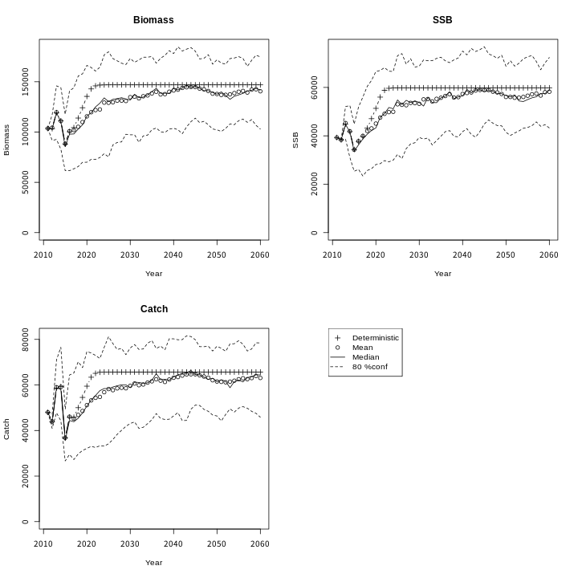

```r
res_future_Fcurrent <- future.vpa(res_vpa,
                      multi=1,
                      nyear=50, # 将来予測の年数
                      start.year=2011, # 将来予測の開始年
                      N=100, # 確率的計算の繰り返し回数=>実際の計算では1000~5000回くらいやってください
                      ABC.year=2019, # ABCを計算する年
                      waa.year=2015:2017, # 生物パラメータの参照年
                      maa.year=2015:2017,
                      M.year=2015:2017,
                      is.plot=TRUE, # 結果をプロットするかどうか
                      seed=1,
                      silent=FALSE,
                      recfunc=HS.recAR, # 再生産関係の関数
                      # recfuncに対する引数
                      rec.arg=list(a=SRmodel.base$pars$a,b=SRmodel.base$pars$b,
                                   rho=SRmodel.base$pars$rho, # ここではrho=0なので指定しなくてもOK
                                   sd=SRmodel.base$pars$sd,resid=SRmodel.base$resid))
```

# MSY管理基準値の計算

- MSY管理基準値計算では，上記の将来予測において，Fcurrentの値に様々な乗数を乗じたF一定方策における平衡状態時の（世代時間×20年を`nyear`で指定します）資源量やそれに対応するF等を管理基準値として算出します
- なので、ここまでのプロセスで、ABC計算のためにきちんとしたオプションを設定したfuture.vpaを実行しておいてください。その返り値`res_future_Fcurrent`をMSY計算では使っていきます
- MSY.est関数の引数の詳細な解説は[こちら](https://ichimomo.github.io/future-rvpa/future-doc-abc.html#msy%E7%AE%A1%E7%90%86%E5%9F%BA%E6%BA%96%E5%80%A4%E3%81%AE%E8%A8%88%E7%AE%97)
- オプション`PGY`(MSYに対する比率を指定) や`B0percent`(B0に対する比率を指定)、`Bempirical`(親魚資源量の絶対値で指定)で、別の管理基準値も同時に計算できます。
- 最近年の親魚量で維持した場合の管理基準値も、比較のためにあとで見るため`Bempirical`で指定しておいてください。また、B_HS(HSの折れ点)や最大親魚量などもここで計算しておいても良いかと。。。

[output not shown]

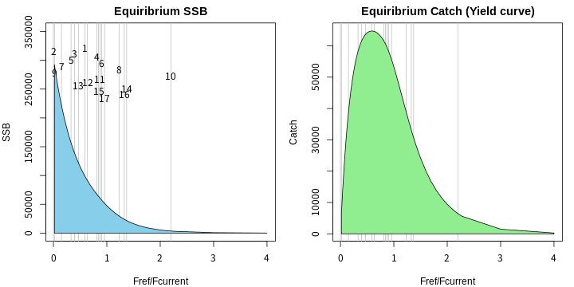

```r
# MSY管理基準値の計算
res_MSY <- est.MSY(res_vpa, # VPAの計算結果
                 res_future_Fcurrent$input, # 将来予測で使用した引数
                 N=100, # 確率的計算の繰り返し回数=>実際の計算では1000~5000回くらいやってください
                 calc.yieldcurve=TRUE,
                 PGY=c(0.95,0.9,0.6,0.1), # 計算したいPGYレベル。上限と下限の両方が計算される
                 onlylower.pgy=FALSE, # TRUEにするとPGYレベルの上限は計算しない（計算時間の節約になる）
                 B0percent=c(0.2,0.3,0.4),
                 Bempirical=c(round(tail(colSums(res_vpa$ssb),n=1)),
                              round(max(colSums(res_vpa$ssb))),
                              24000, # 現行Blimit
                              SRmodel.base$pars$b) # HSの折れ点
                 ) # 計算したいB0%レベル
```

## 結果の表示

- `res_MSY$summary`にすべての結果が入っています。

```r
# 結果の表示(tibbleという形式で表示され、最初の10行以外は省略されます)
options(tibble.width = Inf)
(refs.all <- res_MSY$summary)
```

```
#> # A tibble: 17 x 16
#>    RP_name        RP.definition AR        SSB SSB2SSB0       B      U
#>    <chr>          <chr>         <lgl>   <dbl>    <dbl>   <dbl>  <dbl>
#>  1 MSY            Btarget0      FALSE  98453.   0.324  191222. 0.338
#>  2 B0             <NA>          FALSE 304207.   1      409695. 0
#>  3 PGY_0.95_upper <NA>          FALSE 139195.   0.458  236337. 0.260
#>  4 PGY_0.95_lower <NA>          FALSE  67183.   0.221  152957. 0.402
#>  5 PGY_0.9_upper  <NA>          FALSE 156757.   0.515  255253. 0.228
#>  6 PGY_0.9_lower  <NA>          FALSE  57375.   0.189  137791. 0.423
#>  7 PGY_0.6_upper  <NA>          FALSE 221965.   0.730  324143. 0.120
#>  8 PGY_0.6_lower  Blimit0       FALSE  29436.   0.0968  78491. 0.495
#>  9 PGY_0.1_upper  <NA>          FALSE 292379.   0.961  397458. 0.0163
#> 10 PGY_0.1_lower  Bban0         FALSE   3617.   0.0119  10191. 0.635
#> 11 B0-20%         <NA>          FALSE  60838.   0.200  143472. 0.415
#> 12 B0-30%         <NA>          FALSE  91262.   0.300  182995. 0.353
```

[output cut: 43 more lines]

```r
# 全データをじっくり見たい場合
# View(refs.all)
```

## 管理基準値の選択

```r
# どの管理基準値をどのように定義するか。デフォルトから外れる場合はここで定義する
refs.all$RP.definition[refs.all$RP_name=="B0-20%" & refs.all$AR==FALSE] <- "Btarget1"  # たとえばBtargetの代替値としてB020%も候補に残しておきたい場合
refs.all$RP.definition[refs.all$RP_name=="PGY_0.95_lower" & refs.all$AR==FALSE] <- "Btarget2"
refs.all$RP.definition[refs.all$RP_name=="Ben-19431" & refs.all$AR==FALSE] <- "Bcurrent"
refs.all$RP.definition[refs.all$RP_name=="Ben-63967" & refs.all$AR==FALSE] <- "Bmax"
refs.all$RP.definition[refs.all$RP_name=="Ben-24000" & refs.all$AR==FALSE] <- "Blimit1"
refs.all$RP.definition[refs.all$RP_name=="Ben-51882" & refs.all$AR==FALSE] <- "B_HS"

# 定義した結果を見る
refs.all %>% dplyr::select(RP_name,RP.definition)
```

```
#> # A tibble: 17 x 2
#>    RP_name        RP.definition
#>    <chr>          <chr>
#>  1 MSY            Btarget0
#>  2 B0             <NA>
#>  3 PGY_0.95_upper <NA>
#>  4 PGY_0.95_lower Btarget2
#>  5 PGY_0.9_upper  <NA>
#>  6 PGY_0.9_lower  <NA>
#>  7 PGY_0.6_upper  <NA>
#>  8 PGY_0.6_lower  Blimit0
#>  9 PGY_0.1_upper  <NA>
#> 10 PGY_0.1_lower  Bban0
#> 11 B0-20%         Btarget1
#> 12 B0-30%         <NA>
#> 13 B0-40%         <NA>
#> 14 Ben-21729      <NA>
#> 15 Ben-63967      Bmax
#> 16 Ben-24000      Blimit1
#> 17 Ben-51773      <NA>
```

```r
# refs.allの中からRP.definitionで指定された行だけを抜き出す
(refs.base <- refs.all %>%
    dplyr::filter(!is.na(RP.definition)) %>% # RP.definitionがNAでないものを抽出
    arrange(desc(SSB)) %>% # SSBを大きい順に並び替え
    dplyr::select(RP.definition,RP_name,SSB,SSB2SSB0,Catch,Catch.CV,U,Fref2Fcurrent)) #　列を並び替え
```

```
#> # A tibble: 7 x 8
#>   RP.definition RP_name           SSB SSB2SSB0  Catch Catch.CV     U
#>   <chr>         <chr>           <dbl>    <dbl>  <dbl>    <dbl> <dbl>
#> 1 Btarget0      MSY            98453.   0.324  64722.    0.203 0.338
#> 2 Btarget2      PGY_0.95_lower 67183.   0.221  61486.    0.246 0.402
#> 3 Bmax          Ben-63967      63969.   0.210  60591.    0.256 0.409
#> 4 Btarget1      B0-20%         60838.   0.200  59589.    0.267 0.415
#> 5 Blimit0       PGY_0.6_lower  29436.   0.0968 38833.    0.436 0.495
#> 6 Blimit1       Ben-24000      23999.   0.0789 33203.    0.464 0.513
#> 7 Bban0         PGY_0.1_lower   3617.   0.0119  6472.    0.523 0.635
#>   Fref2Fcurrent
#>           <dbl>
#> 1         0.592
#> 2         0.815
#> 3         0.843
#> 4         0.871
#> 5         1.23
#> 6         1.33
#> 7         2.20
```

# デフォルトルールを使った将来予測

```r
# デフォルトのHCRはBtarget0,Blimit0,Bban0のセットになるので、それを使って将来予測する
input.abc <- res_future_Fcurrent$input # Fcurrentにおける将来予測の引数をベースに将来予測します
input.abc$multi <- derive_RP_value(refs.base,"Btarget0")$Fref2Fcurrent # currentFへの乗数を"Btarget0"で指定した値に
input.abc$HCR <- list(Blim=derive_RP_value(refs.base,"Blimit0")$SSB,
                      Bban=derive_RP_value(refs.base,"Bban0")$SSB,
                      beta=0.8,
                      year.lag=0)
future.default <- do.call(future.vpa,input.abc) # デフォルトルールの結果→図示などに使う
```

[output not shown]

[output cut: 106 more lines]

[output not shown]

[figure not shown]

```r
## 網羅的将来予測の実施
# default
kobeII.data <- beta.simulation(input.abc,
                               beta_vector=seq(from=0.1,to=1,by=0.1),
                               year.lag=0)

kobeII.table <- make_kobeII_table(kobeII.data,res_vpa,
                                 Btarget=derive_RP_value(res_MSY$summary,"Btarget0")$SSB,
                                 Blimit=derive_RP_value(res_MSY$summary,"Btarget0")$SSB,
                                 Bban=derive_RP_value(res_MSY$summary,"Btarget0")$SSB,
                 year.catch=2019:2030,
                 year.ssb  =2019:2030,
                 year.Fsakugen  =2019:2030,
                 year.ssbtarget  =2019:2030,
                 year.ssblimit  =2019:2030,
                 year.ssbban  =2019:2030,
                 year.ssbmax  =2019:2030,
                 year.ssbmin  =2019:2030,
                 year.aav  =2019:2030)

## csvファイルに一括して出力する場合
out.vpa(res=res_vpa,
        msyres=res_MSY,
        fres_current=res_future_current,
        fres_HCR=res_future_0.8HCR,
        kobeII=kobeII.table,
        filename="vpa")
```